title: “Case 4Intelligence

```r
#install.packages("readxl")
#install.packages("tidyverse")
#install.packages("tidyr")
#install.packages("dplyr")
#install.packages("zoo")
#install.packages("seasonal")

library(readxl)
library(tidyverse)
library(tidyr)
library(dplyr)
library(zoo)
library(seasonal)
```

— A base de dados fornecida é um arquivo de formato xlsx, que contém três sheets, Diesel, Gasolina e Etanol, respectivamente. Antes de iniciar a aálise de vizualização é necessário realizar uma etapa de pré-processamento. Iremos importar cada um dos sheets do arquivo em formato de data frame, assim, separaando-os por tipo de combustível e facilitando a análise. Após isso, é necessário transformar a estrutura dos dados no formato apropriado para séries temporais, isto é, será necessário “empilha-los”, também conhecido como tidy data.

```r
df_diesel <- read_xlsx("dados_desafiodatascientistintern_vendas_distribuidoras_anp.xlsx")
df_gasolina <- read_xlsx("dados_desafiodatascientistintern_vendas_distribuidoras_anp.xlsx", sheet = "gasolina")
df_etanol <- read_xlsx("dados_desafiodatascientistintern_vendas_distribuidoras_anp.xlsx", sheet = "etanol")

df_diesel_tidy <- gather(df_diesel, Ano, Diesel, -regiao, -meses)
df_gasolina_tidy <- gather(df_gasolina, Ano, Gasolina, -regiao, -meses)
df_etanol_tidy <- gather(df_etanol, Ano, Etanol, -regiao, -meses)

df_diesel_tidy$Data <- as.yearmon(paste(df_diesel_tidy$Ano, df_diesel_tidy$meses), "%Y %m")
df_gasolina_tidy$Data <- as.yearmon(paste(df_gasolina_tidy$Ano, df_gasolina_tidy$meses), "%Y %m")
df_etanol_tidy$Data <- as.yearmon(paste(df_etanol_tidy$Ano, df_etanol_tidy$meses), "%Y %m")

df_diesel_tidy <- df_diesel_tidy[ ,-2:-3]
df_gasolina_tidy <- df_gasolina_tidy[ ,-2:-3]
df_etanol_tidy <- df_etanol_tidy[ ,-2:-3]

str(df_diesel_tidy)
```

```
## tibble [2,268 × 3] (S3: tbl_df/tbl/data.frame)
##  $ regiao: chr [1:2268] "df" "df" "df" "df" ...
##  $ Diesel: num [1:2268] 23311 25968 24591 24976 27225 ...
##  $ Data  : 'yearmon' num [1:2268] jan 2000 fev 2000 mar 2000 abr 2000 ...
```

```r
str(df_gasolina_tidy)
```

```
## tibble [2,268 × 3] (S3: tbl_df/tbl/data.frame)
##  $ regiao  : chr [1:2268] "df" "df" "df" "df" ...
##  $ Gasolina: num [1:2268] 39258 49570 48423 48553 51085 ...
##  $ Data    : 'yearmon' num [1:2268] jan 2000 fev 2000 mar 2000 abr 2000 ...
```

```r
str(df_etanol_tidy)
```

```
## tibble [2,268 × 3] (S3: tbl_df/tbl/data.frame)
##  $ regiao: chr [1:2268] "df" "df" "df" "df" ...
##  $ Etanol: num [1:2268] 11688 13408 13389 12681 13047 ...
##  $ Data  : 'yearmon' num [1:2268] jan 2000 fev 2000 mar 2000 abr 2000 ...
```

```r
df_diesel_tidy$Data <- as.Date(df_diesel_tidy$Data)
df_gasolina_tidy$Data <- as.Date(df_gasolina_tidy$Data)
df_etanol_tidy$Data <- as.Date(df_etanol_tidy$Data)
```

— Com a base de dados pronta, partiremos para a etapa de vizualização dos dados. Com o objetivo de melhor entendimento do mercado de combustíveis, iremos criar gráficos para cada UF disponível no arquivo, além do nível nacional (br). Analisando as séries em nível nacional, para um entendiento geral do mercado de combustíveis, pode-se notar um comportamente semelhante entre as séries, com um forte componente sazonal no último trimestre do ano, sobretudo em dezembro/novembro, onde a venda de combustíveis costuma atingir seu máximo anual, e também um componente sazonal de baixa no primeiro trimestre do ano, sobretudo em janeiro/fevereiro, onde normalmente as vendas de combustível no brasil atingem a mínima anual. É interessante destacar que para o álcool e gasolina, o pico anual costuma ocorrer em dezembro, provavelmente por conta da característica do mercado, onde esses combustíveis são majoritariamente utilizados em veículos de passeio, assim, dezembro costuma ser um mês de férias, onde muitas famílias viajam, o que pode explicar essa sazonalidade. Já com relação ao Diesel, nota-se que essa alta ocorre novembro/outubro, infere-se que essa alta acompanha o movimento do setor industrial e varejista que costuma se preparar para as vendas de black friday e vendas de final de ano. Essa sazonalidade é identificada também no comportamento dos estados, apesar disso, os estados possuem bastante diferenciação com relação à variância das observações, por exemplo, o diesel no estado do para possui uma amplitude vizualmente identificada bem menor do que o estado de São Paulo, por exemplo.

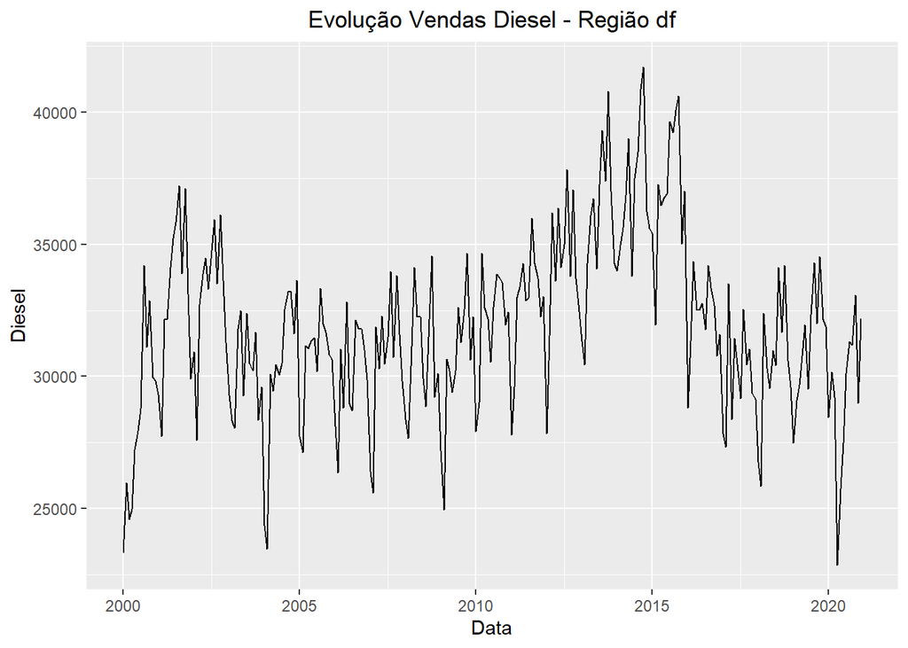

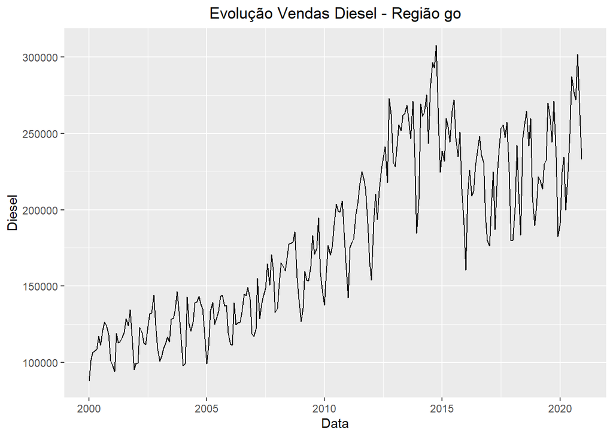

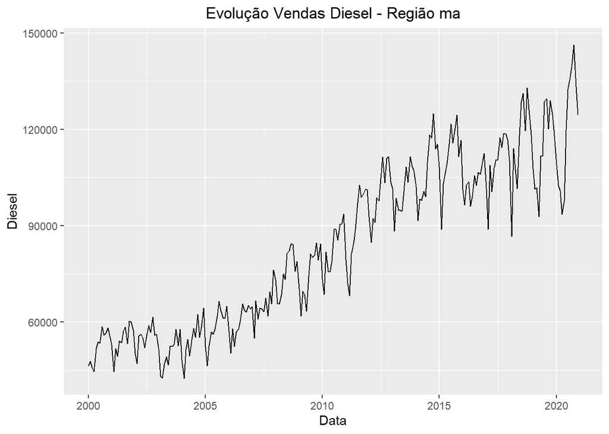

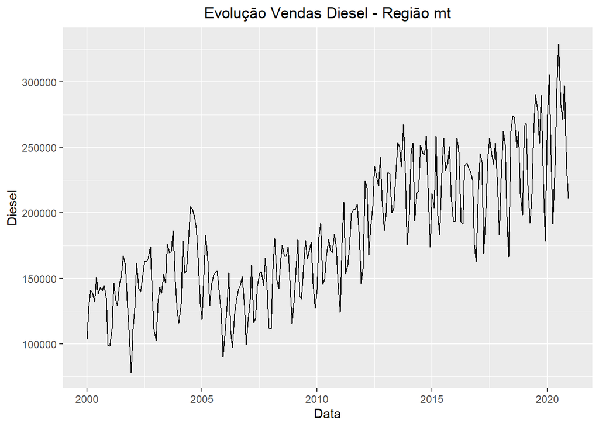

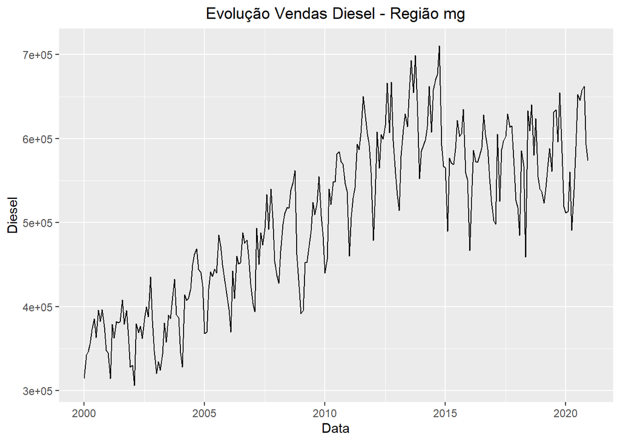

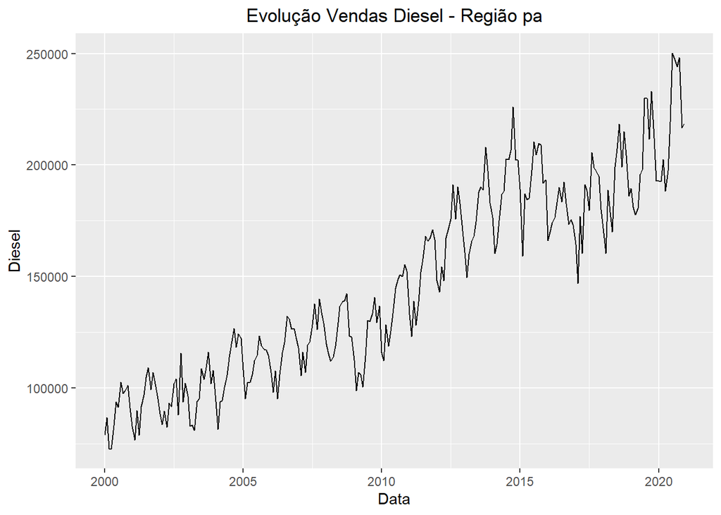

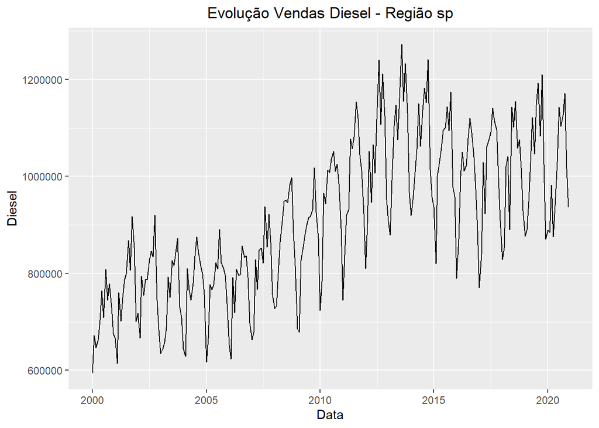

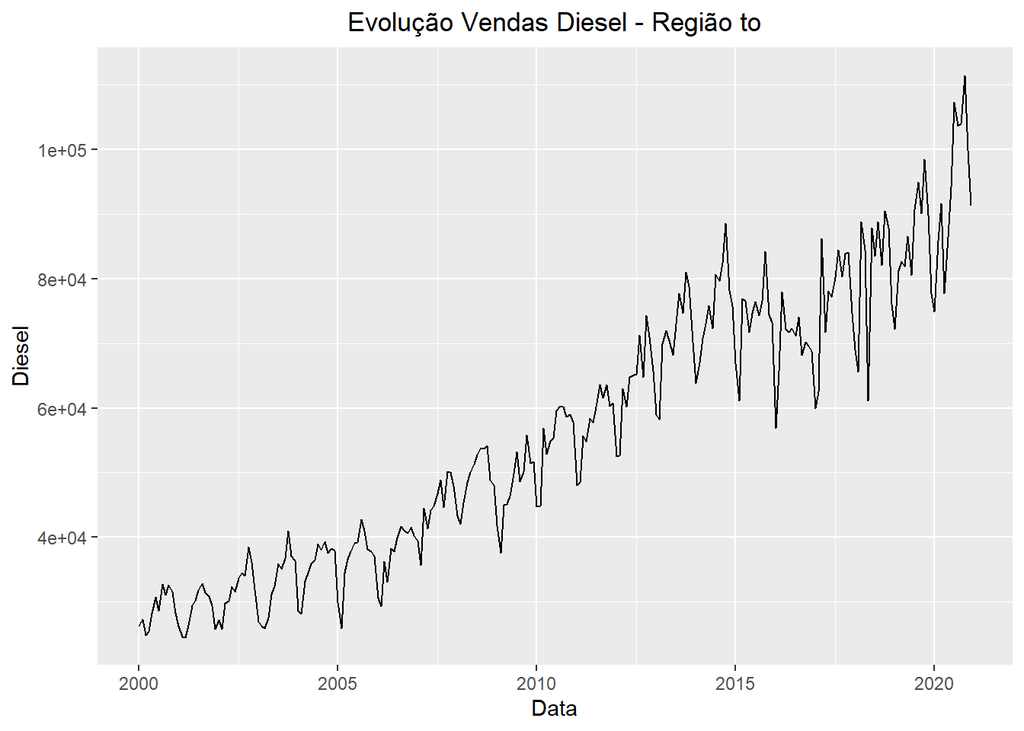

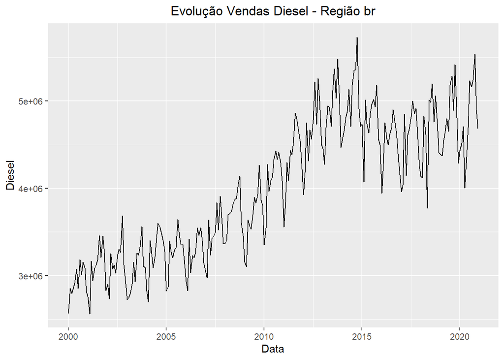

```r
#série original Diesel
for (i in unique(df_diesel_tidy$regiao)) {
  print(ggplot(df_diesel_tidy %>% filter(regiao == i), aes(Data, Diesel)) +
          geom_line() + ggtitle(paste("Evolução Vendas Diesel - Região", i, sep = " ")) + theme(plot.title = element_text(hjust = 0.5)))
}
```

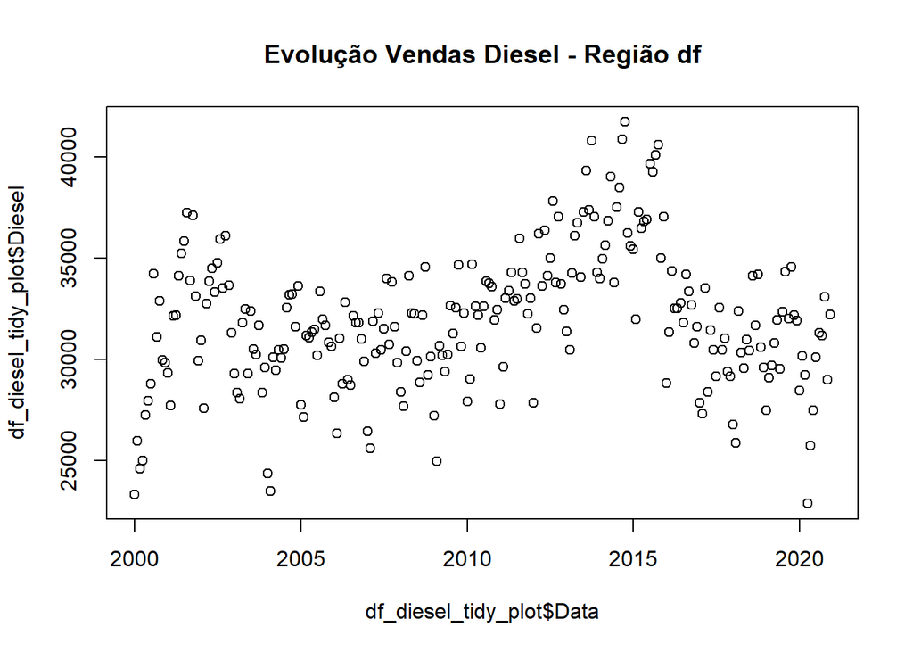

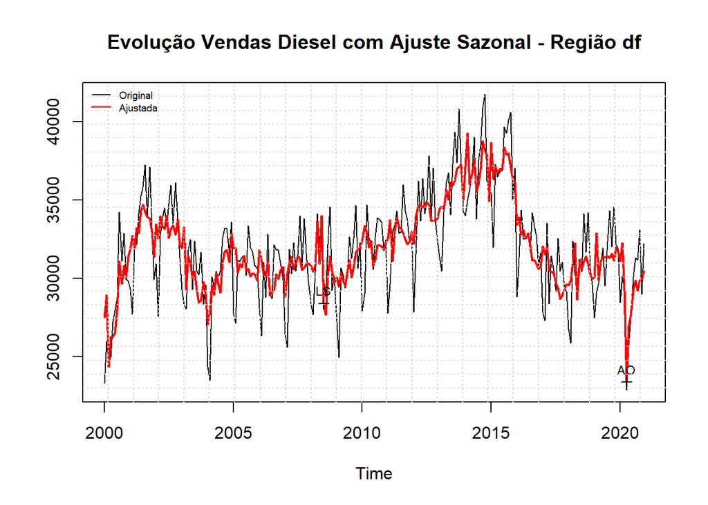

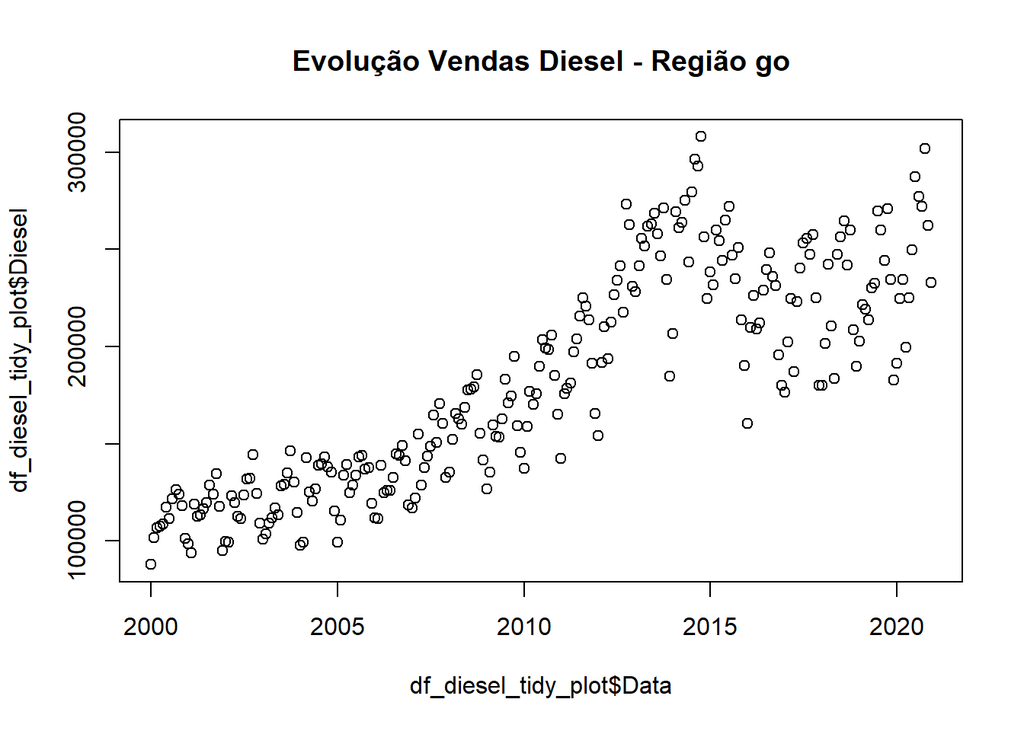

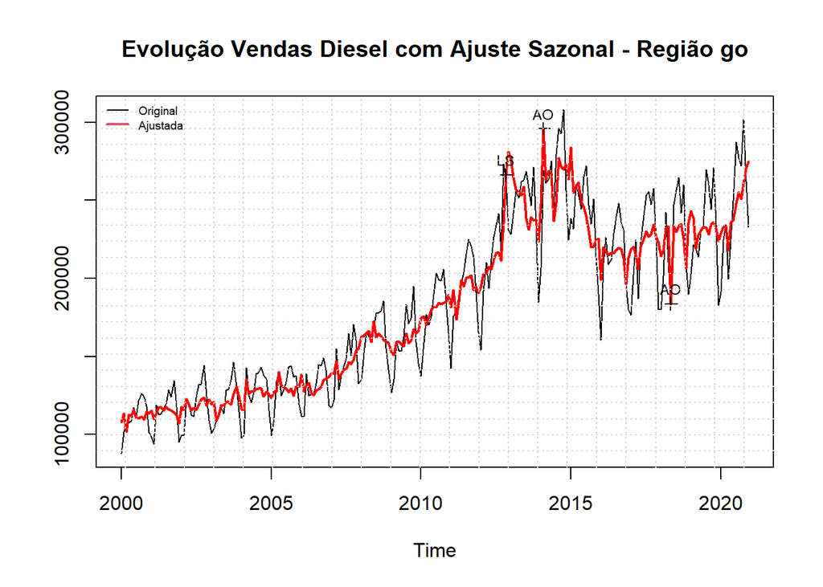

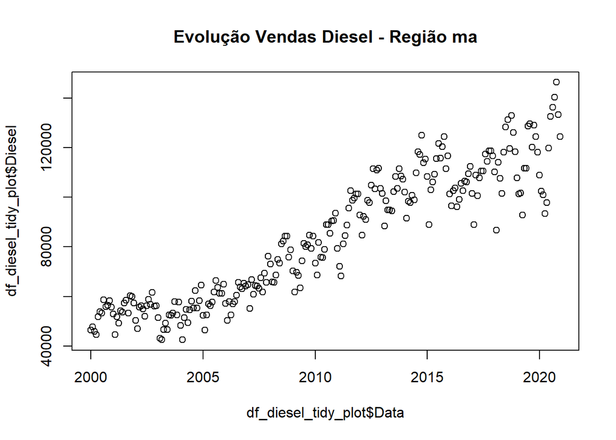

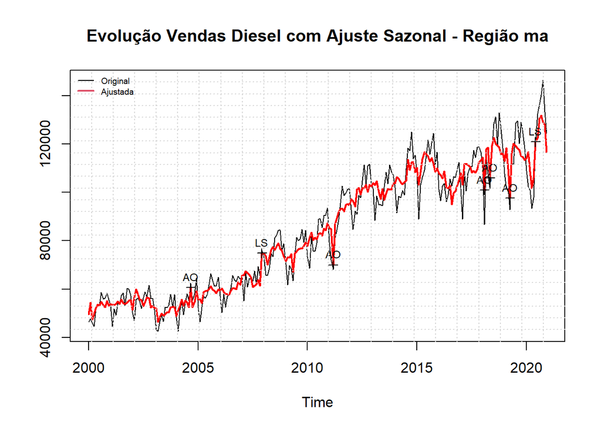

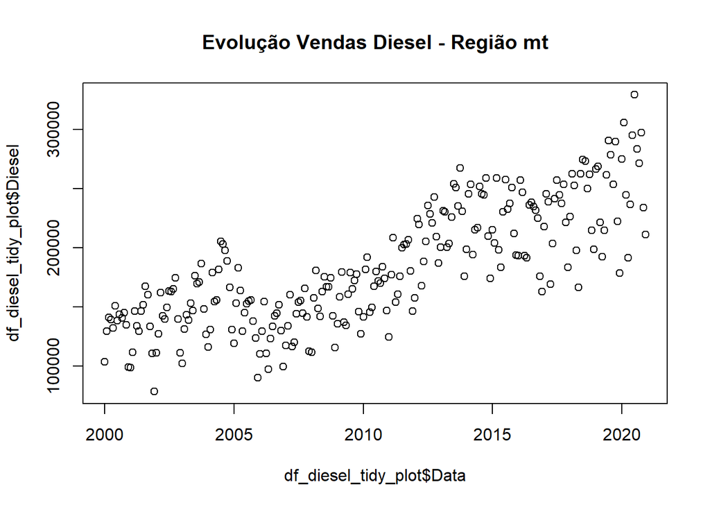

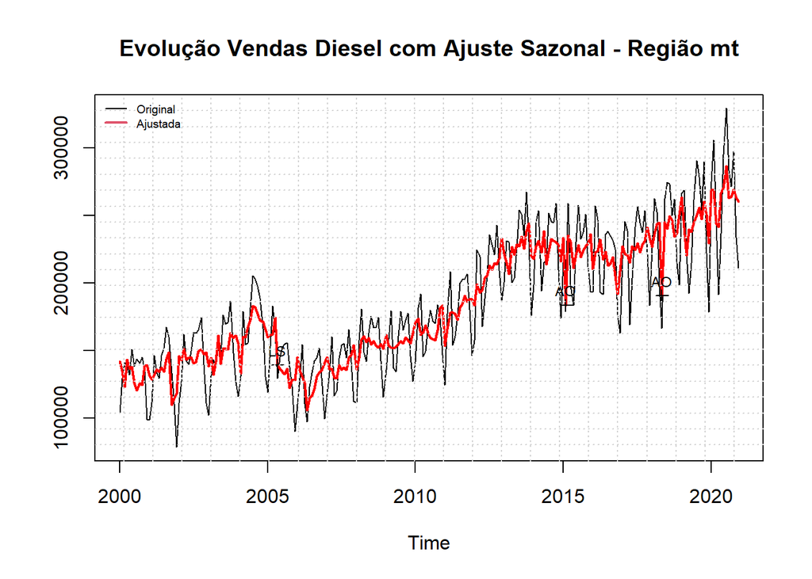

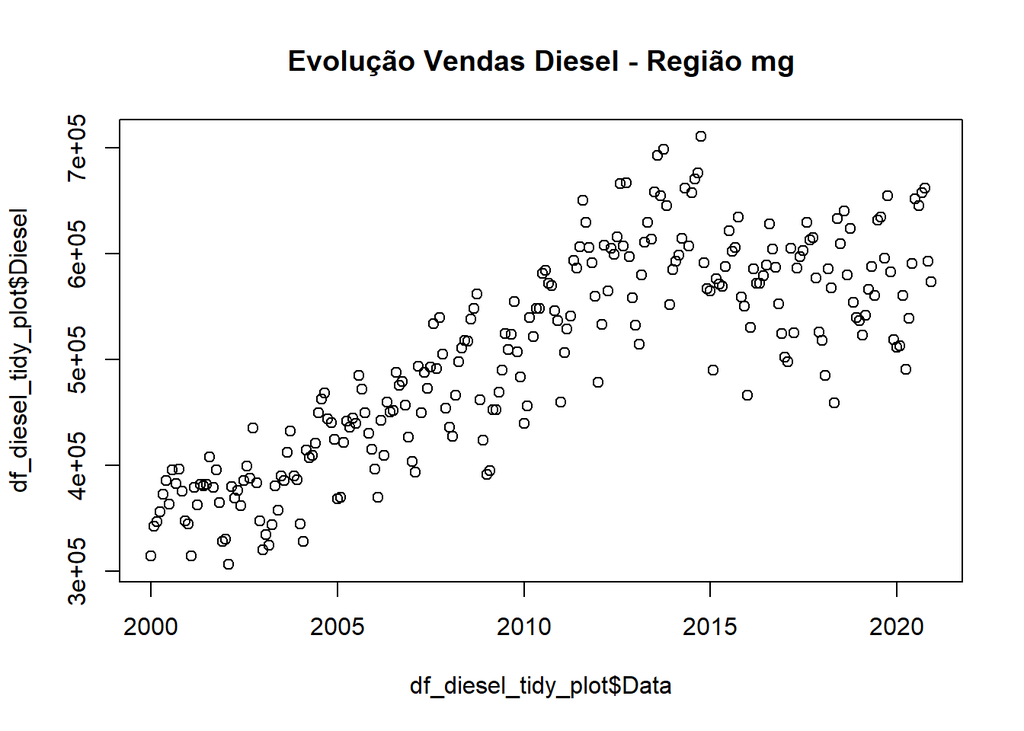

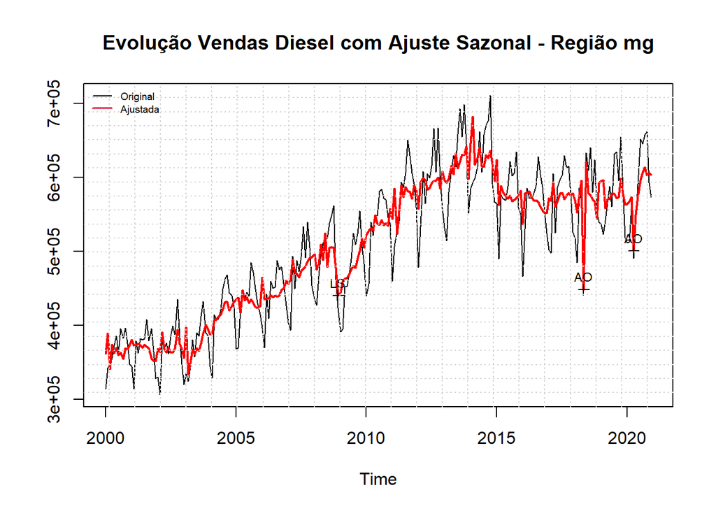

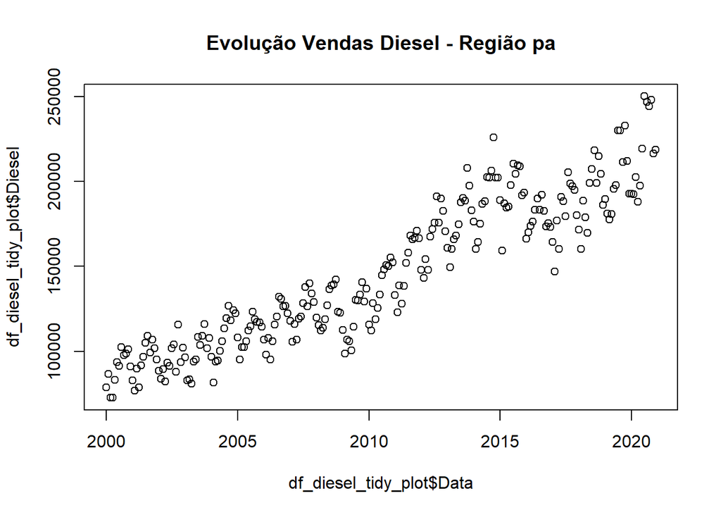

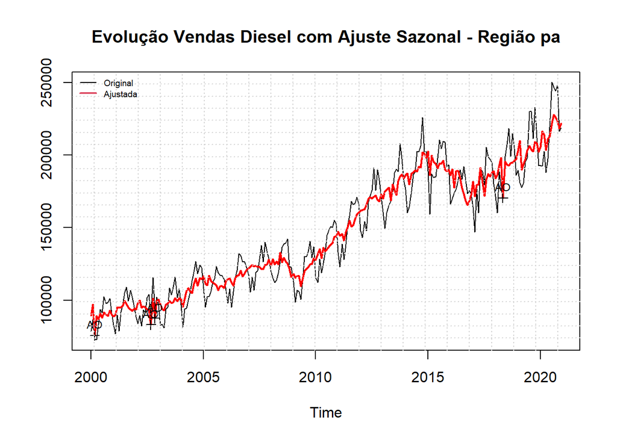

[6 more figures not shown]

```r
#Por região: série original vs ajuste sazonal (Diesel)
for (i in unique(df_diesel_tidy$regiao)) {
  df_diesel_tidy_plot <- df_diesel_tidy %>% filter(regiao == i)
  plot(df_diesel_tidy_plot$Data, df_diesel_tidy_plot$Diesel, main = paste("Evolução Vendas Diesel - Região", i, sep = " "))

  regiao_br <- ts(df_diesel_tidy_plot$Diesel, start = c(2000, 1) , frequency = 12)
  dessaz_br <- seas(regiao_br, x11 = "")
  plot(dessaz_br, main = paste("Evolução Vendas Diesel com Ajuste Sazonal - Região", i, sep = " "))
  grid(nx = 23)
  legend("topleft", legend = c("Original", "Ajustada"), col = c(1, 2), lwd = c(1, 2),
         lty = 1, bty = "n", cex = 0.6)
}
```

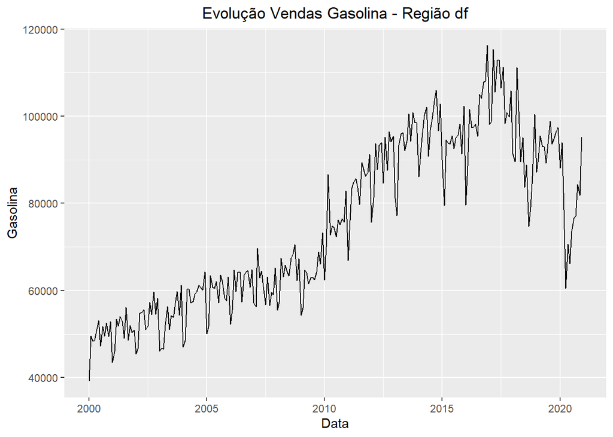

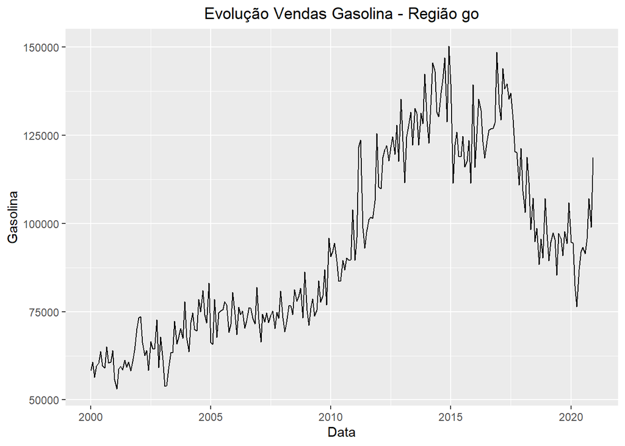

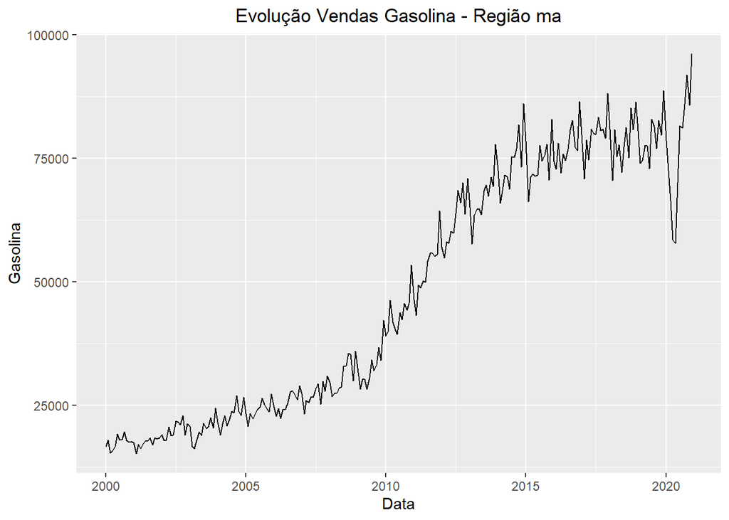

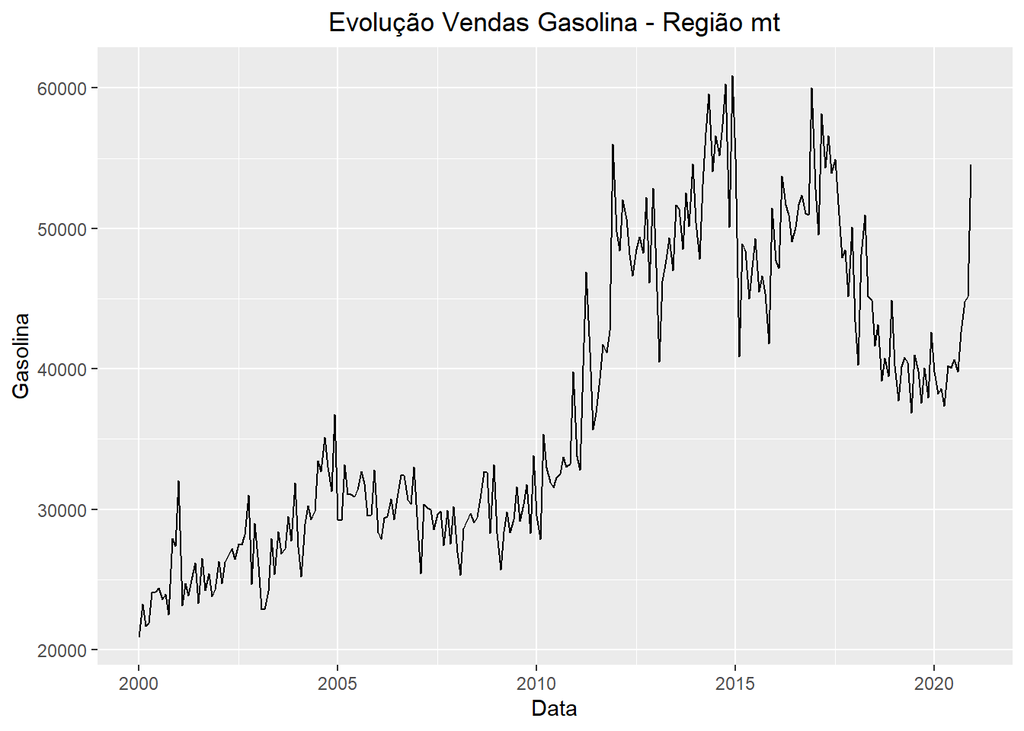

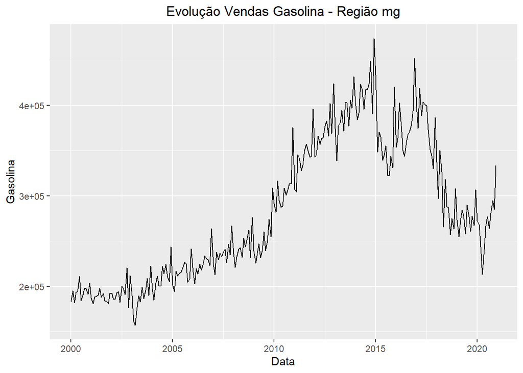

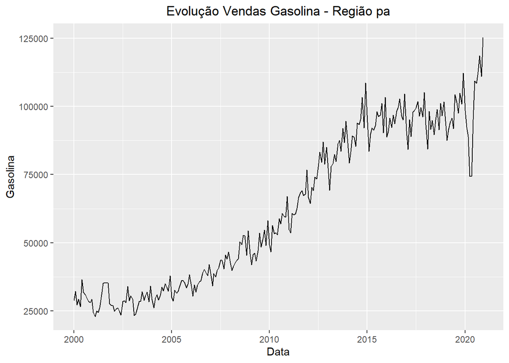

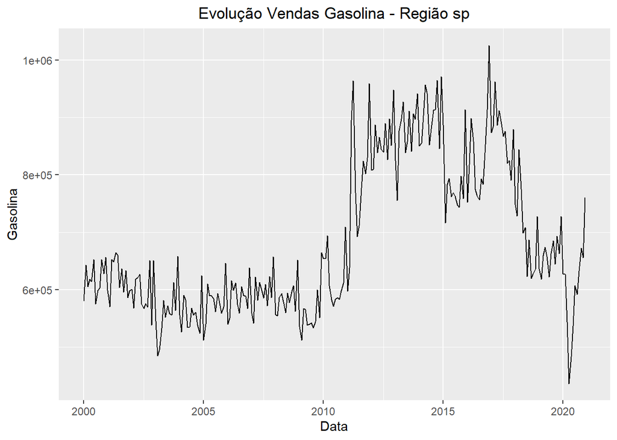

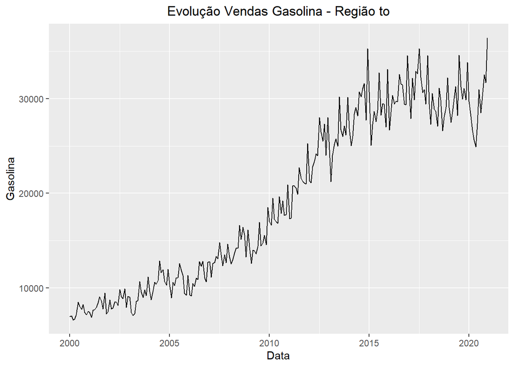

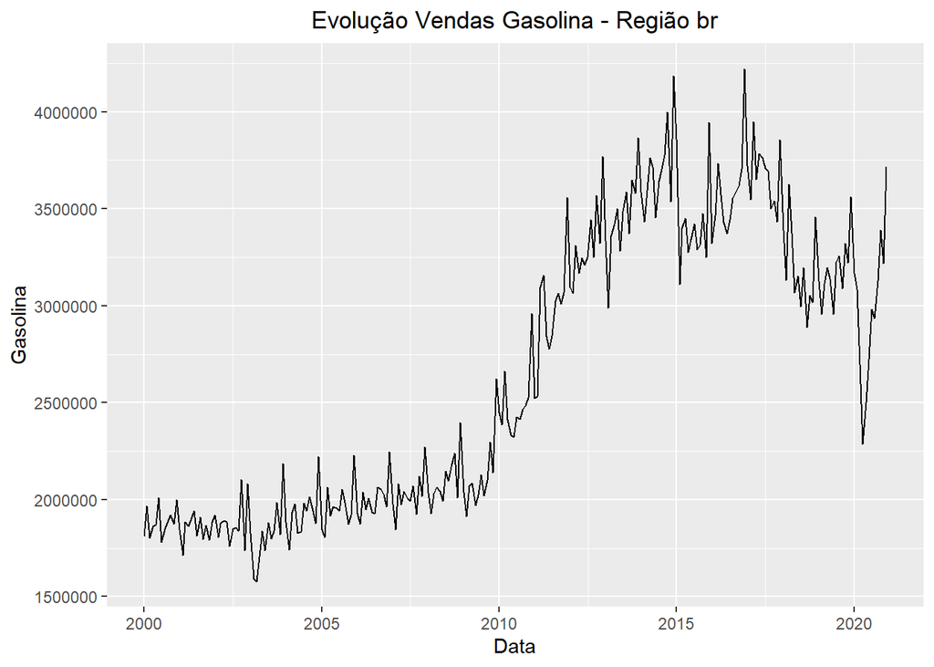

```r
#série original Gasolina
for (i in unique(df_gasolina_tidy$regiao)) {
  print(ggplot(df_gasolina_tidy %>% filter(regiao == i), aes(Data, Gasolina)) +
          geom_line() + ggtitle(paste("Evolução Vendas Gasolina - Região", i, sep = " ")) + theme(plot.title = element_text(hjust = 0.5)))
}
```